# 7.9 Exercises

# Exercise 9

This question uses the variable **dis** (the weighted mean of distances to five Boston employment centers) and **nox** (nitrogen oxides concentration in parts 10 million) from the **Boston** data. We will treat **dis** as the predictor and **nox** as the response.

```r
# The Boston data is in the MASS library
library(MASS)
```

1. Use the **poly()** function to fit a cubic polynomial regression to predict **nox** using **dis**. Report the regression output and plot the resulting data and polynomial fits.

```r
cubic.fit = lm(nox ~ poly(dis, 3), data = Boston)
coef(cubic.fit)
```

```
##   (Intercept) poly(dis, 3)1 poly(dis, 3)2 poly(dis, 3)3
##     0.5546951    -2.0030959     0.8563300    -0.3180490
```

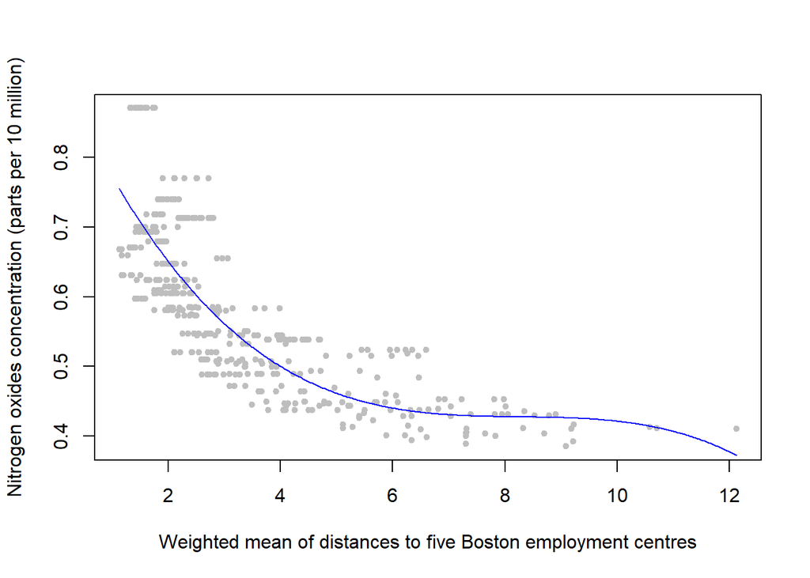

```r
plot(Boston$dis, Boston$nox, xlab = 'Weighted mean of distances to five Boston employment centres', ylab = 'Nitrogen oxides concentration (parts per 10 million)', col = 'grey', pch = 20)
x = seq(from = min(Boston$dis), to = max(Boston$dis), length.out = 500)
y = predict(cubic.fit, data.frame(dis = x))
lines(x, y, col = 'blue')
```

2. Plot the polynomial fits for a range of different polynomial degrees (say, from 1 to 10) and report the associated residual sum of squares.

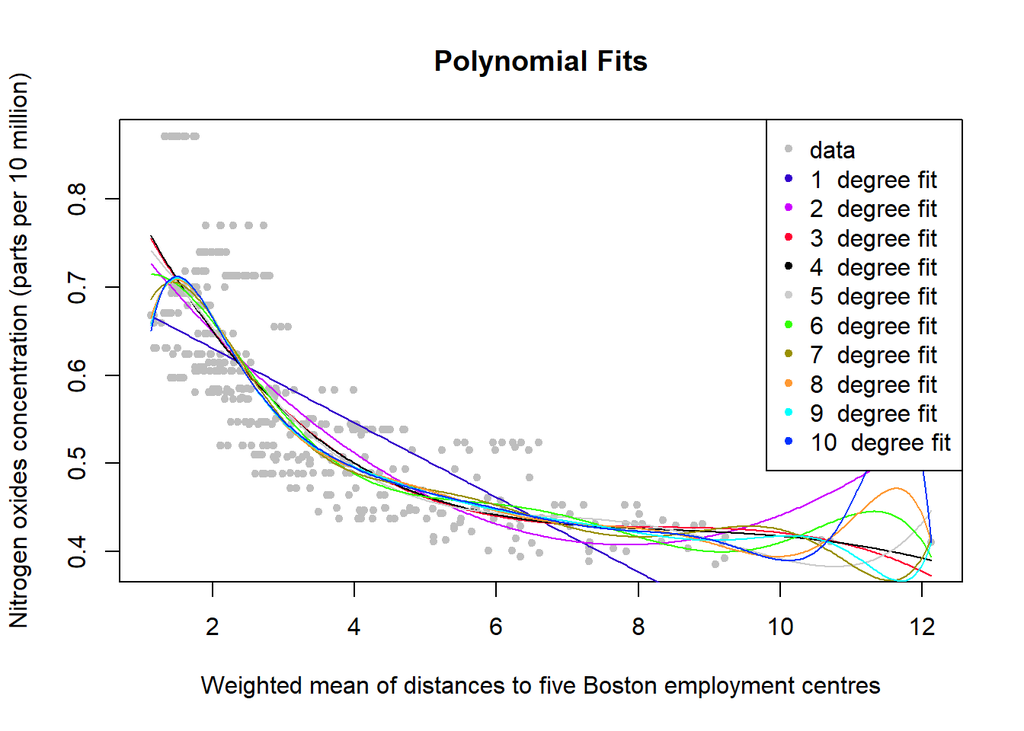

```r
max.degree = 10
rss = rep(0, max.degree)
legend.labels = c('data')
legend.colors = c('grey', '#3300CC', '#CC00FF', '#FF0033', '#000000', '#CCCCCC', '#33FF00', '#999000', '#FF9933', '#00FFFF', '#0033FF')
plot(Boston$dis, Boston$nox, xlab = 'Weighted mean of distances to five Boston employment centres', ylab = 'Nitrogen oxides concentration (parts per 10 million)', main = 'Polynomial Fits', col = legend.colors[1], pch = 20)
for (d in 1:max.degree){
  this.fit = lm(nox ~ poly(dis, d), data = Boston)
  legend.labels = cbind(legend.labels, c(paste(d, ' degree fit')))
  rss[d] = sum(this.fit$residuals^2)
  y = predict(this.fit, data.frame(dis = x))
  lines(x, y, col = legend.colors[d + 1])
}
legend('topright', legend = legend.labels, col = legend.colors, pch = 20)
```

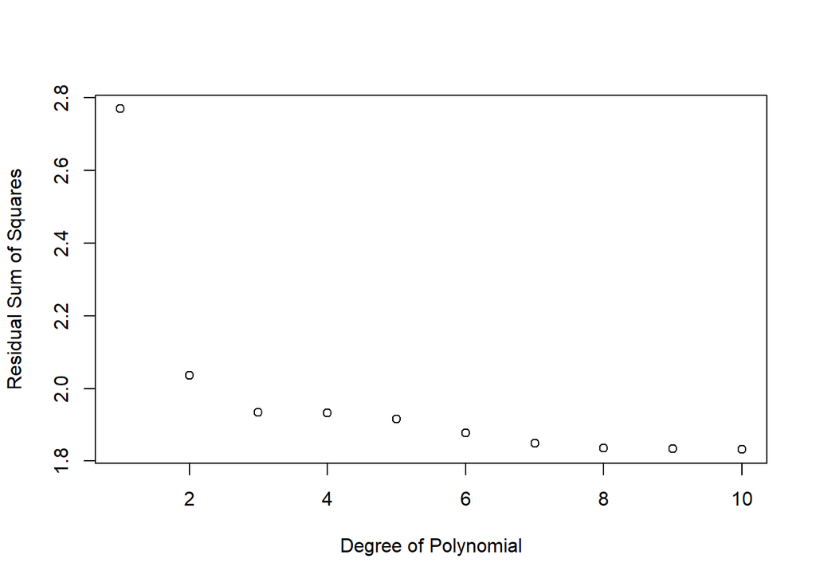

```r
plot(rss, xlab = 'Degree of Polynomial', ylab = 'Residual Sum of Squares')
```

```r
rss
```

```
##  [1] 2.768563 2.035262 1.934107 1.932981 1.915290 1.878257 1.849484
##  [8] 1.835630 1.833331 1.832171
```

```r
which.min(rss)
```

```
## [1] 10
```

*Of course, since rss is always going to favor a more flexible model, we see the rss decreasing monotonically. However, we definitely seem some diminishing returns after about the 3rd degree.*

3. Use the **bs()** function to fit a regression spline to predict **nox** using **dis**. Report the output for the fit using four degrees of freedom. How did you choose the knots? Plot the resulting fit.

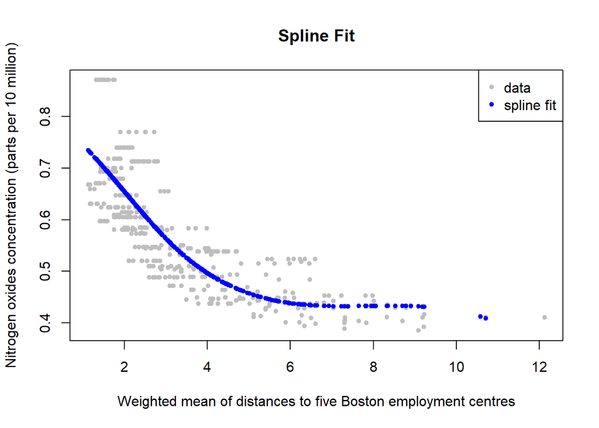

```r
# Let's just choose uniformly distributed knots
spline.fit = lm(nox ~ bs(dis, df = 4, degree = 3), data = Boston)
plot(Boston$dis, Boston$nox, xlab = 'Weighted mean of distances to five Boston employment centres', ylab = 'Nitrogen oxides concentration (parts per 10 million)', main = 'Spline Fit', col = 'grey', pch = 20)
points(Boston$dis, spline.fit$fitted.values, col = 'blue', pch = 20)
legend('topright', legend = c('data', 'spline fit'), col = c('grey', 'blue'), pch = 20)
```

```r
sum(spline.fit$residuals^2)
```

```
## [1] 1.922775
```

*The RSS for the spline with 4 degrees of freedom is 1.922775, which is between the RSS values of the quartic and quintic polynomial fits.*

5. Now fit a regression spline for a range of degrees of freedom and plot the resulting fits and report the resulting RSS. Describe the results obtained.

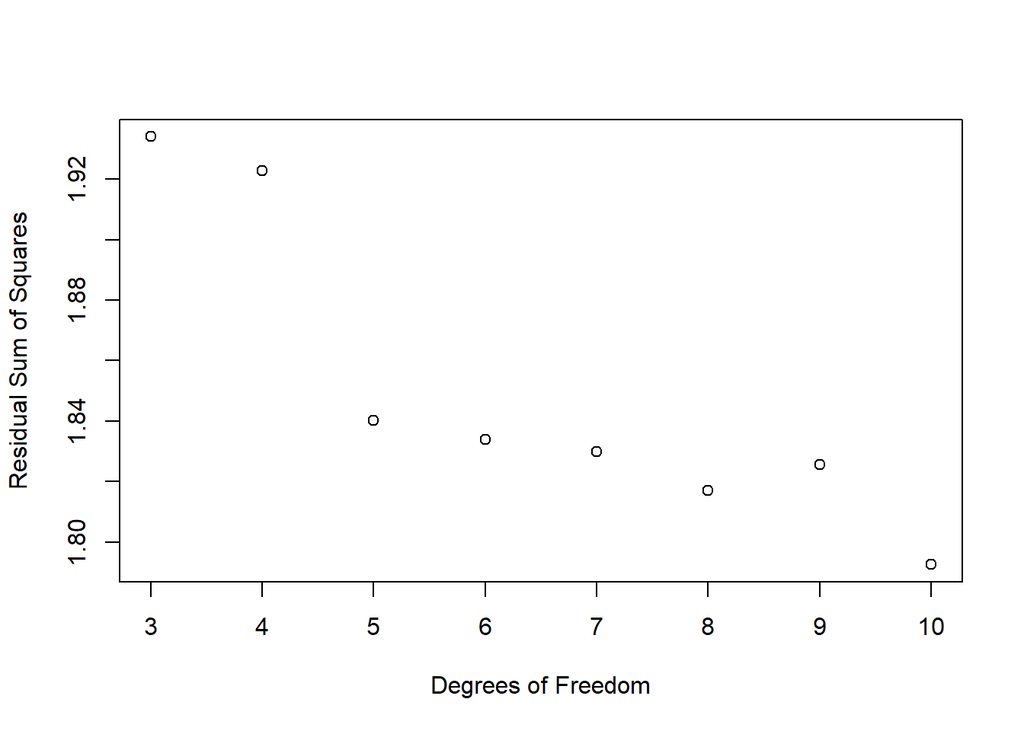

```r
max.df = 10
min.df = 3
rss = rep(0, max.df - min.df)
for (df in min.df:max.df){
  this.fit = lm(nox ~ bs(dis, df = df, degree = 3), data = Boston)
  rss[df - min.df + 1] = sum(this.fit$residuals^2)
}

plot(min.df:max.df, rss, xlab = 'Degrees of Freedom', ylab = 'Residual Sum of Squares')
```

```r
rss
```

```
## [1] 1.934107 1.922775 1.840173 1.833966 1.829884 1.816995 1.825653 1.792535
```

6. Perform cross-validation or another approach in order to select the best degrees of freedom for a regression spline on this data. Describe your results.

```r
min.error = Inf
best.df = 0

set.seed(1)
for (df in min.df:max.df){
  this.fit = glm(nox ~ bs(dis, df = df, degree = 3), data = Boston)
  this.error = cv.glm(Boston, this.fit, K = 10)$delta[1]
  if (this.error < min.error){
    min.error = this.error
    best.df = df
  }
}
best.df
```

```
## [1] 6
```

*Our 10-fold CV has selected 6 degrees of freedom to be the best for this data set. This selection is not very surprising, since we saw that after about 5 degrees of freedom, you’re really not getting much of a better fit on the training data. Therefore, any further flexibility added will probably only fit on noise.*

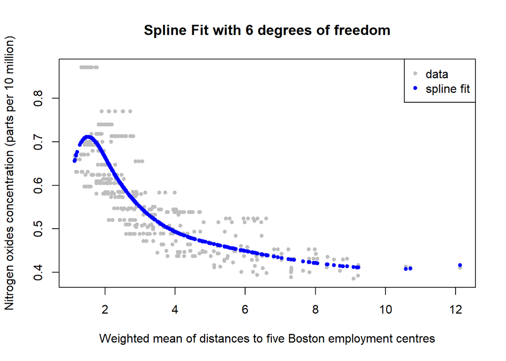

```r
plot(Boston$dis, Boston$nox, xlab = 'Weighted mean of distances to five Boston employment centres', ylab = 'Nitrogen oxides concentration (parts per 10 million)', main = paste('Spline Fit with', best.df, 'degrees of freedom'), col = 'grey', pch = 20)
points(Boston$dis, lm(nox ~ bs(dis, df = best.df, degree = 3), data = Boston)$fitted.values, col = 'blue', pch = 20)
legend('topright', legend = c('data', 'spline fit'), col = c('grey', 'blue'), pch = 20)
```

# Exercise 10

This question relates to the **College** data set.

1. Split the data into a training set and a test set. Using out-of-state tuition as the response and the other variables as the predictors, perform forward stepwise selection on the training set in order to identify a statisfactory model that uses just a subset of the predictors.

```r
# Create a training set sample
set.seed(1)
train = sample(1:nrow(College), nrow(College)/2)
```

```r
# Perform forward stepwise selection on training set
library(leaps)
```

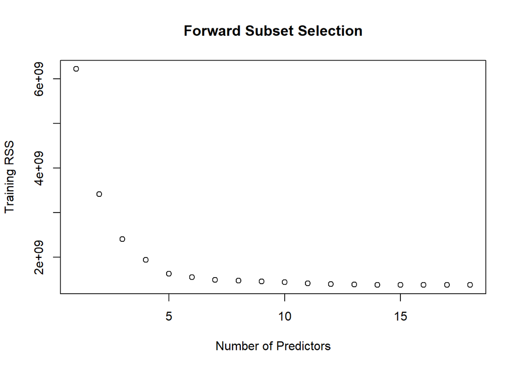

```r
forward.fit = regsubsets(Outstate ~ ., data = College, subset = train, nvmax = ncol(College) - 1, method = 'forward')

# Plot the training RSS
plot(forward.fit$rss, xlab = 'Number of Predictors', ylab = 'Training RSS', main = 'Forward Subset Selection')
```

*Training RSS starts to level off after about 5 or 6 predictors.*

```r
coef(forward.fit, id = 5)
```

```
##   (Intercept)    PrivateYes    Room.Board      Terminal   perc.alumni
## -3385.7476246  2886.3710107     1.0778380    39.8449982    73.4864560
##        Expend
##     0.2271547
```

*The 5 predictor model fit with forward selection includes the following predictors: whether or not the school is private (Private), room and board costs (Room.Board), the percentage of faculty with a terminal degree (Terminal), the percentage of alumni who donate (perc.alumni), and instructional expenditure per student (Expend).*

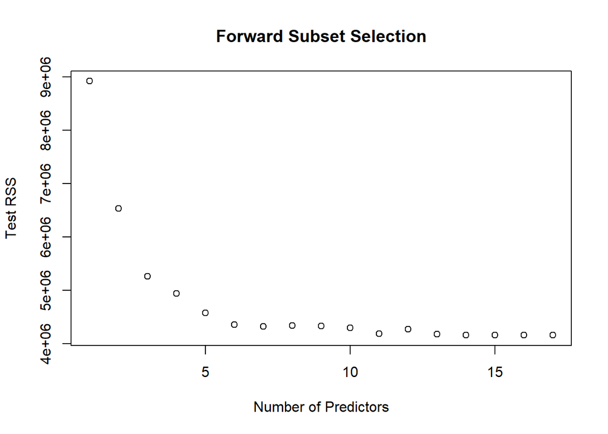

```r
# Look at the RSS from the test data for each fit
forward.rss = rep(NA, ncol(College) - 1)
for (i in 1:(ncol(College) - 1)){
  coefi = coef(forward.fit, id = i)
  pred = model.matrix(Outstate ~ ., College[-train,])[,names(coefi)]%*%coefi
  forward.rss[i] = mean((College[-train, 'Outstate'] - pred)^2)
}

# and plot it
plot(forward.rss, xlab = 'Number of Predictors', ylab = 'Test RSS', main = 'Forward Subset Selection')
```

```r
# Find the model that minimizes test RSS
forward.id = which.min(forward.rss)
forward.id
```

```
## [1] 16
```

```r
coef(forward.fit, id = forward.id)
```

```
##   (Intercept)    PrivateYes          Apps        Accept        Enroll
## -1.617326e+03  2.226286e+03 -2.906482e-01  6.883981e-01 -5.459847e-02
##     Top10perc     Top25perc   F.Undergrad   P.Undergrad    Room.Board
##  2.129152e+01 -7.640046e+00 -1.459014e-01  1.598473e-01  9.451305e-01
##      Personal           PhD      Terminal     S.F.Ratio   perc.alumni
## -3.257992e-01  8.461606e+00  2.738663e+01 -8.980559e+01  5.475181e+01
##        Expend     Grad.Rate
##  1.797878e-01  3.077929e+01
```

*With 16 predictors, we mimize the test RSS. The only predictor left out of this model is the estimated book costs.*

2. Fit a GAM on the training data, using out-of-state tuition as the response and the features selected in the previous step as the predictors. Plot the results and explain your findings.

```r
# Use CV to identify the best 4 spline fit with the coefficients from the 5 predictor forward selection model (Private is a qualitative predictor, so it doesn't get a spline)
n.pred = 4
df.min = 3
df.max = 10
df.array = rep(df.min, n.pred)
min.error = Inf

set.seed(1)
for (index.start in n.pred:1){
  for (index in index.start:n.pred){
    for (df in df.min:df.max){
      df.array[index] = df
      this.fit = glm(Outstate ~ Private + bs(Room.Board, df.array[1]) + bs(Terminal, df.array[2]) + bs(perc.alumni, df.array[3]) + bs(Expend, df.array[4]), data = College[train,])
      this.error = cv.glm(College[train,], this.fit, K = 10)$delta[1]
      if (this.error < min.error){
        min.error = this.error
        best.fit = this.fit
        best.df = df.array
      }
    }
  }
}
best.df
```

```
## [1] 3 3 3 6
```

*Our CV chose splines with only 3 degrees of freedom for all but the Expend predictor. This suggests that perhaps we may use less flexible models for these other predictors.*

3. Evaluate the model obtained on the test set and explain the results obtained.

```r
# Compare the test rss from our gam model to the test rss values from forward selection
gam.pred = predict(best.fit, College[-train,])
```

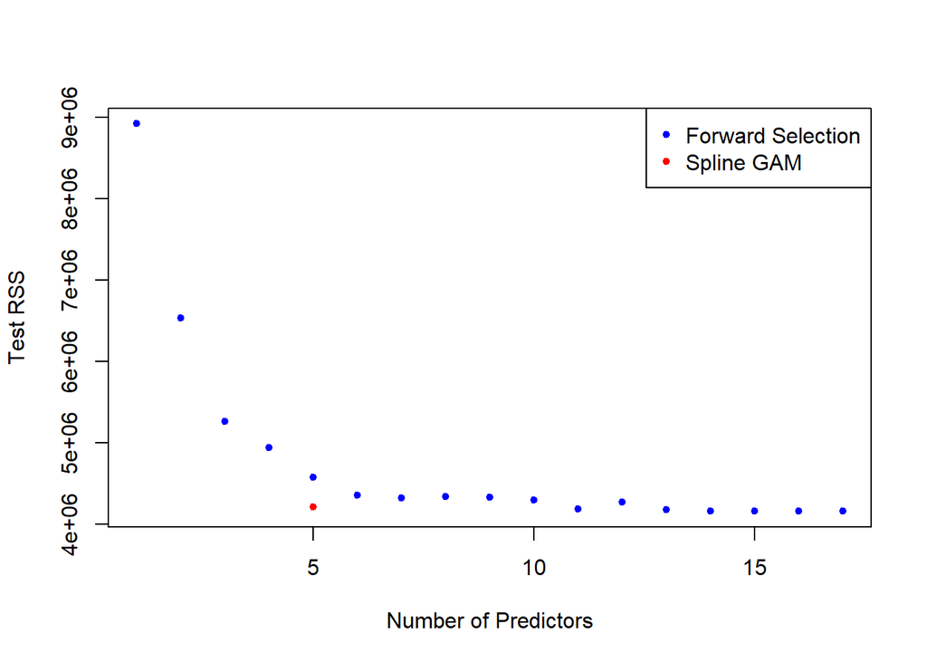

```r
gam.rss = mean((College[-train, 'Outstate'] - gam.pred)^2)

plot(forward.rss, xlab = 'Number of Predictors', ylab = 'Test RSS', col = 'blue', pch = 20)
points(5, gam.rss, col = 'red', pch = 20)
legend('topright', legend = c('Forward Selection', 'Spline GAM'), col = c('blue', 'red'), pch = 20)
```

*We can see that our gam model with 5 predictors performs about as well as the forward selection model with 11+ predictors.*

4. For which variables, if any, is there evidence of a non-linear relationship with the response?

*Our CV results selecting 6 degrees of freedom for the Expend predictor certainly suggests a non-linear relationship there. Since our CV only selected 3 degrees of freedom (the minimum we allowed) for the other predictors, they could potentially have more linear relationships. Let’s investigate.*

```r
# Room.Board
fit.1 = lm(Outstate ~ Room.Board, data = College)
fit.2 = lm(Outstate ~ poly(Room.Board, 2), data = College)
fit.3 = lm(Outstate ~ poly(Room.Board, 3), data = College)
anova(fit.1, fit.2, fit.3)
```

```
## Analysis of Variance Table
##
## Model 1: Outstate ~ Room.Board
## Model 2: Outstate ~ poly(Room.Board, 2)
## Model 3: Outstate ~ poly(Room.Board, 3)
##   Res.Df        RSS Df Sum of Sq      F  Pr(>F)
## 1    775 7183272136
## 2    774 7140568331  1  42703806 4.6283 0.03176 *
## 3    773 7132209438  1   8358892 0.9059 0.34149
## ---
## Signif. codes:  0 '***' 0.001 '**' 0.01 '*' 0.05 '.' 0.1 ' ' 1
```

*There is some evidence of a non-linear relationship between Outstate and Room.Board. A spline fit was probably too flexible for our GAM.*

```r
# Terminal
fit.1 = lm(Outstate ~ Terminal, data = College)
fit.2 = lm(Outstate ~ poly(Terminal, 2), data = College)
fit.3 = lm(Outstate ~ poly(Terminal, 3), data = College)
anova(fit.1, fit.2, fit.3)
```

```
## Analysis of Variance Table
##
## Model 1: Outstate ~ Terminal
## Model 2: Outstate ~ poly(Terminal, 2)
## Model 3: Outstate ~ poly(Terminal, 3)
##   Res.Df        RSS Df Sum of Sq       F    Pr(>F)
## 1    775 1.0469e+10
## 2    774 9.8785e+09  1 590346535 46.6531 1.716e-11 ***
## 3    773 9.7815e+09  1  96947465  7.6614  0.005776 **
## ---
## Signif. codes:  0 '***' 0.001 '**' 0.01 '*' 0.05 '.' 0.1 ' ' 1
```

*There is strong evidence of a non-linear relationship, perhaps even a cubic relationship, between Outstate and Terminal. It seems like a spline fit in our GAM may have been a good idea.*

```r
# perc.alumni
fit.1 = lm(Outstate ~ perc.alumni, data = College)
fit.2 = lm(Outstate ~ poly(perc.alumni, 2), data = College)
fit.3 = lm(Outstate ~ poly(perc.alumni, 3), data = College)
anova(fit.1, fit.2, fit.3)
```

```
## Analysis of Variance Table
##
## Model 1: Outstate ~ perc.alumni
## Model 2: Outstate ~ poly(perc.alumni, 2)
## Model 3: Outstate ~ poly(perc.alumni, 3)
##   Res.Df        RSS Df Sum of Sq      F Pr(>F)
## 1    775 8532119379
## 2    774 8531988926  1    130453 0.0118 0.9134
## 3    773 8529439311  1   2549614 0.2311 0.6309
```

*There is no strong evidence of a non-linear relationship between Outstate and perc.alumni. We probably should not have modeled a spline relationship in our GAM.*

# Exercise 11

In Section 7.7, it was mentioned that GAMs are generally fit using a *backfitting* approach. The idea behind backfitting is actually quite simple. We will now explore backfitting in the context of multiple linear regression.

Suppose that we would like to perform multiple linear regression, but we do not have software to do so. Instead, we only have software to perform simple linear regression. Therefore, we take the following iterative approach: we repeatedly hold all but one coefficient estimate fixed at its current value, and update only that coefficient estimate using a simple linear regression. The process is continued until *convergence* - that is, until the coefficient estimates stop changing.

We now try this out on a toy example.

1. Generate a response $Y$ and two predictors $X_1$ and $X_2$, with $n = 100$.

```r
set.seed(1)
n = 100
x1 = rnorm(n)
x2 = rnorm(n)
epsilon = rnorm(n)
beta0 = 0.5
beta1 = 1.0
beta2 = 1.5
y = beta0 + beta1 * x1 + beta2 * x2 + epsilon
```

*The true relationship is* $Y = 0.5 + 1.0 X_1 + 1.5 X_2 + \epsilon$.

2. Initialize $\hat{\beta_1}$ to take on a value of your choice. It does not matter what value you choose.

```r
beta1.hat = .9
```

3. Keeping $\hat{\beta_1}$ fixed, fit the model
   $$Y - \hat{\beta_1} X_1 = \beta_0 + \beta_2 X_2 + \epsilon$$
   . You can do this as follows:

```
a = y - beta1 * x1
beta2 = lm(a ~ x2)$coef[2]
```

```r
a = y - beta1.hat * x1
beta2.hat = lm(a ~ x2)$coef[2]
beta2.hat
```

```
##      x2
## 1.44642
```

*With just one iteration (with an erroneous* $\hat{\beta_1}$*), we already get close to the true* $\hat{\beta_2}$ *value of 1.5*.

4. Keeping $\hat{\beta_2}$ fixed, fit the model
   $$Y - \hat{\beta_2} X_2 = \beta_0 + \beta_1 X_1 + \epsilon$$
   . You can do this as follows:

```
a = y - beta2 * x2
beta1 = lm(a ~ x1)$coef[2]
```

```r
a = y - beta2.hat
beta1.hat = lm(a ~ x1)$coef[2]
beta1.hat
```

```
##       x1
## 1.019576
```

*Using the estimated* $\hat{\beta_2}$ *of 1.44642, we get our* $\hat{\beta_1}$ *much closer to the true value*.

5. Write a for loop to repeat (c) and (d) 1,000 times. Report the estimates of $\hat{\beta_0}$, $\hat{\beta_1}$, and $\hat{\beta_2}$ at each iteration of the for loop. Create a plot in which each of these values is displayed, with $\hat{\beta_0}$, $\hat{\beta_1}$, and $\hat{\beta_2}$ each shown in a different color.

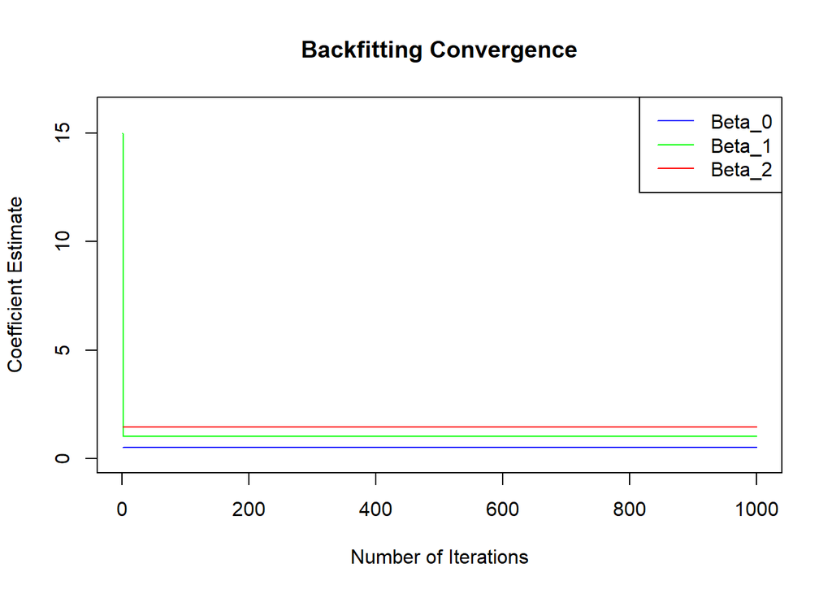

```r
iterations = 1000
beta0.hat = rep(NA, iterations)
beta1.hat = rep(NA, iterations)
beta2.hat = rep(NA, iterations)

# Since those estimates were quite close after just one iteration, let's start a fairly bad estimate
beta1.hat[1] = 15

for (i in 1:iterations){
  a = y - beta1.hat[i] * x1
  beta2.hat[i] = lm(a ~ x2)$coef[2]
  a = y - beta2.hat[i] * x2
  fit = lm(a ~ x1)
  if (i < iterations){
    beta1.hat[i + 1] = fit$coef[2]
  }
  beta0.hat[i] = fit$coef[1]
}

plot(beta0.hat, xlab = 'Number of Iterations', ylab = 'Coefficient Estimate', main = 'Backfitting Convergence', col = 'blue', lty = 1, type = 'l', ylim = c(0, max(rbind(beta0.hat, beta1.hat, beta2.hat)) + 1))
lines(beta1.hat, col = 'green', lty = 1)
lines(beta2.hat, col = 'red', lty = 1)
legend('topright', legend = c('Beta_0', 'Beta_1', 'Beta_2'), col = c('blue', 'green', 'red'), lty = 1)
```

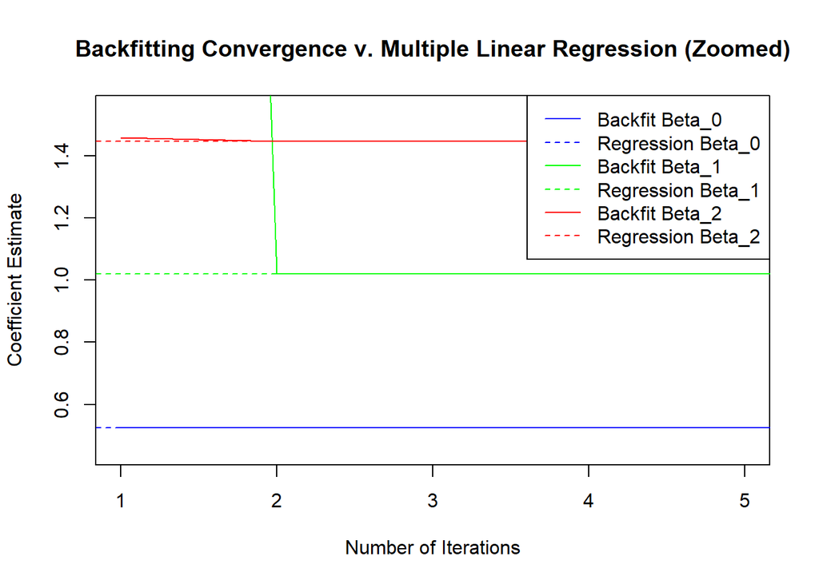

```r
lm.fit = lm(y ~ x1 + x2)

plot(beta0.hat, xlab = 'Number of Iterations', ylab = 'Coefficient Estimate', main = 'Backfitting Convergence v. Multiple Linear Regression (Zoomed)', col = 'blue', lty = 1, type = 'l', ylim = c(.45, 1.55), xlim = c(1, 5))
lines(beta1.hat, col = 'green', lty = 1)
lines(beta2.hat, col = 'red', lty = 1)
abline(h = lm.fit$coef[1], lty = 2, col = 'blue')
abline(h = lm.fit$coef[2], lty = 2, col = 'green')
abline(h = lm.fit$coef[3], lty = 2, col = 'red')
legend('topright', legend = c('Backfit Beta_0', 'Regression Beta_0', 'Backfit Beta_1', 'Regression Beta_1', 'Backfit Beta_2', 'Regression Beta_2'), col = c('blue', 'blue', 'green', 'green', 'red', 'red'), lty = c(1, 2, 1, 2, 1, 2))
```

```r
data.frame(parameter = c('Beta0', 'Beta1', 'Beta2'), true.value = c(beta0, beta1, beta2), backfit.value = c(beta0.hat[iterations], beta1.hat[iterations], beta2.hat[iterations]), lm.value = lm.fit$coef)
```

```
##             parameter true.value backfit.value  lm.value
## (Intercept)     Beta0        0.5     0.5253534 0.5253534
## x1              Beta1        1.0     1.0211102 1.0211102
## x2              Beta2        1.5     1.4465332 1.4465332
```

*You can see that the backfit values converge to the same parameter estimates as the multiple linear regression.*

7. On this data set, how many backfitting iterations were required in order to obtain a “good” approximation to the multiple regression coefficient estimates?

```r
index = cbind(1:5, c(iterations))
beta0.hat[index]
```

```
##  [1] 0.5258447 0.5253534 0.5253534 0.5253534 0.5253534 0.5253534 0.5253534
##  [8] 0.5253534 0.5253534 0.5253534
```

```r
beta1.hat[index]
```

```
##  [1] 15.000000  1.021124  1.021110  1.021110  1.021110  1.021110  1.021110
##  [8]  1.021110  1.021110  1.021110
```

```r
beta2.hat[index]
```

```
##  [1] 1.459567 1.446533 1.446533 1.446533 1.446533 1.446533 1.446533
##  [8] 1.446533 1.446533 1.446533
```

*You can see that after just 2 iterations, the estimates get to their final values. Obviously, 1000 iterations was a bit excessive.*

# Exercise 12

This problem is a continuation of the previous exercise. In a toy example with $p = 100$, show that one can approximate the multiple linear regression coefficient estimates by repeatedly performing simple linear regression in a backfitting procedure. How many backfitting iterations are required in order to obtain a “good” approximation to the multilpe regression coefficient estimates? Create a plot to justify your answer.

```r
# Number of predictors
p = 100
# Number of observations
n = p * p

# Create matrix of observations
set.seed(1)
x = matrix(nrow = n, ncol = p)
for (col in 1:p){
  x[,col] = rnorm(n)
}

# Create error term (since there are so many predictors, we'll give the error a bit more standard deviation to be significant)
epsilon = rnorm(n, sd = 10)

# Create array of true beta values
beta = rnorm(p)

# Create the response (note that beta0 = 0; i.e. no intercept term in the true relationship)
y = x %*% beta + epsilon

# Get the multiple linear regression fit
lm.fit = lm(y ~ x)
lm.estimates = lm.fit$coef[-1]
lm.magnitude = sqrt(sum(lm.estimates^2))
```

```r
# Initialize parameter estimates, the first estimates will be all 0, the mean value used to initialize the true beta values
beta.hat = rep(0, p)

# We'll keep track of the "percentage distance" between the estimated parameter vector from the multiple linear regression and the estimated parameter vector from each iteration of the backfitting
# When this percentage distance is <=1%, we'll stop iterating
this.distance = Inf
percentage.distance = c()
iterations = 0
threshold = .01
while (this.distance > threshold){
  for (j in 1:p){
    a = y - x[,-j] %*% beta.hat[-j]
    beta.hat[j] = lm(a ~ x[,j])$coef[2]
  }
  this.distance = sqrt(sum((lm.estimates - beta.hat)^2)) / lm.magnitude
  iterations = iterations + 1
  percentage.distance[iterations] = this.distance
}

iterations
```

```
## [1] 2
```

```r
percentage.distance
```

```
## [1] 0.065960394 0.003692198
```

*It turns out it only takes 2 iterations of backfitting to get our estimated parameter vector within 1% of the multiple linear regression estimated parameters. In fact, the second iterations got within 0.37% - pretty good.*

```r
# Let's also compare the residual sum of squares between the two
lm.rss = sum(lm.fit$residuals^2)
backfit.rss = sum((y - x %*% beta.hat)^2)
print(paste('Multiple linear regression:', lm.rss))
```

```
## [1] "Multiple linear regression: 989276.095966121"
```

```r
print(paste('Backfit with', iterations, 'iterations:', backfit.rss))
```

```
## [1] "Backfit with 2 iterations: 989657.890330064"
```

```r
print(paste('% Delta:', (backfit.rss - lm.rss) * 100 / lm.rss))
```

```
## [1] "% Delta: 0.0385933073183128"
```

*The delta between the RSS of the multiple linear regression and the backfit is also very small (less than .039%).*

*I know that the problem statement asked for some plots to verify, but since it only took 2 iterations, it’s really not worthwhile to plot.*